# Plutonic rocks of the Arabian Shield

# Regional Granite Suites

- The late- to posttectonic granites are organised into regional suites defined by geography, age, composition, and tectonic setting.
- Despite local variation, they share a broadly similar petrologic range:
  - granodiorite → monzogranite → syenogranite → alkali-feldspar granite
- Reflecting progressive magmatic evolution from mildly calc-alkaline to highly evolved A-type compositions

### The Midyan Region (~638–575 Ma)

- The Midyan terrane (northwestern shield) contains approximately 80 large late- to posttectonic felsic plutons
  - Divided into suites of regional extent
- Rock types include:
  - alkali-feldspar granite, alkali granite, monzogranite, granodiorite, trondhjemite
- Specialised plutons host:
  - Mo, Nb, REE, Sn, Ta, U, W, Zr
  - Locations: Ghurayyah, Jabal Tawlah, Jabal Hamra
- Alkali granites identified by:
  - sodic amphibole (riebeckite)
  - clinopyroxene (aegirine)
- Dabbagh complex (577±13 Ma):
  - Massive Ediacaran alkali-feldspar granite
  - Forms a large massif rising 750 m above surrounding valleys
  - Typical morphology: prominent inselbergs and massifs
  - In contrast, granodiorite and monzogranite weather to low-relief grus surfaces
- In Jordan, Midyan-equivalent granitoids:
  - Aqaba complex (640–600 Ma): subduction-related, high-K calc-alkaline
  - Araba complex (600–560 Ma): bimodal calc-alkaline to alkaline
  - Separated by an unconformity marking transition to extensional magmatism

### The Ha’il Region

- Late- to posttectonic granitoids divided into five suites
- Jabal Aja:
  - One of the largest bodies of alkali-feldspar granite and alkali granite in the Arabian Shield (566±4 Ma)
- Salma complex:
  - Peralkaline ring intrusion
  - Biotite alkali granite and syenogranite
  - Contains comenditic ash-flow tuffs erupted during caldera collapse
  - Example of preserved plutonic and coeval volcanic record
- Representative ages:
  - 638±18 Ma (Tindahah)
  - 635±4 Ma (Kawr)

### The Haml Batholith (Eastern Shield / Khida Terrane Core)

- Vast assemblage forming the core of the Khida terrane
- Isotopically distinct:
  - Indicates Paleoproterozoic crust beneath juvenile ANS
- Regional gravity low correlates with the batholith
  - Indicates large volumes of low-density granitic magma
- Divided into two suites:
  - Haml suite (predominant):
    - monzogranite to granodiorite (~640–625 Ma)
    - younger monzogranite to syenogranite with local alkali-feldspar granite (~615–600 Ma)
  - Nasaf suite:
    - tonalite, granodiorite, gabbro
    - near northeastern margin
- Central batholith hosts lithium-mica granites enriched in:
  - Li, F, Rb, Y, Sn, W
- Economic targets:
  - Huqban pluton (Sn, REE)
  - Dahul pluton (Sn, Ta, Mo, W)
- Early magmatism:
  - granite (659±7 Ma)
  - quartz porphyry (646±11 Ma)
  - SHRIMP U-Pb dates at Ad Duwayhi

### The Asir Region

- Late- to posttectonic granites compiled into:
  - Ibn Hashbal suite (~640–615 Ma)
  - Wadbah suite (~605 Ma)
- Both suites are posttectonic relative to the 680–640 Ma Nabitah orogenic event
- Alkali-feldspar granites in Asir:
  - Emplaced earlier than in central and northern shield
  - Indicates non-synchronous petrogenetic transitions across terranes
- Jabal Tha (Jabal al Gaharrah):
  - Muscovite syenogranite (606±2 Ma)
  - Notable tin-bearing pluton

# Late- to Post-tectonic Gabbro Complexes

- Gabbro constitutes approximately 6% of the Arabian Shield
- Late- to post-tectonic gabbros are distinguished from syn-tectonic ophiolitic gabbros by:
  - prominent magmatic layering
  - discordant contacts
  - circular to ovoid ring-dike geometries
- Implying emplacement controlled by extensional tectonics rather than subduction
- Several complexes are significant targets for:
  - titaniferous magnetite, chromite, nickel, PGM, vanadium

### Key Complexes & Economic Potential

- Thalath Complex (central shield)
  - Circular to ovoid bodies, up to 50 km across
  - Prominent inward-dipping gabbro-dunite layering
  - At least one has a gabbro core and anorthosite rim (ring-dike geometry)
- Lakathah Complex (SW shield)
  - Nearly circular ring-dike, 10 km across
  - Pyroxenite-hornblendite core
  - Diorite-gabbro intermediate zone
  - Outer syenite ring
  - Concordant titaniferous magnetite lenses up to 3 m thick and 50 m long
- Wadi Kamal Complex (NW shield)
  - Norite, anorthosite, gabbro, leucogabbro
  - Target for titaniferous magnetite (up to 12% Ti, 0.30–1.21% V2O5)
  - Adjacent ultramafic body prospective for Ni and PGM
- Ad Dawadimi / Al Ji’lani Gabbro (E shield)
  - Oval ring structure, 7 km across
  - Inward-dipping norite and gabbro cumulate layers (>3 km thickness)
  - Host to Ad Dawadimi silver veins
  - Plagioclase-pyroxene gabbro cumulate predominates
- Jabal Sha’i’ Gabbro (S shield)
  - Layered intrusion
  - Typical posttectonic character

### Petrogenesis and Tectonic Significance

- Layered cumulate structure records fractional crystallisation
  - Denser minerals settle first from a mafic magma reservoir
- Association of titaniferous magnetite and vanadiferous oxides (Wadi Kamal, Lakathah):
  - Consistent with late-stage oxide crystallisation
  - Occurs in iron-rich differentiates of tholeiitic parental magmas
- Ring-dike geometries (Lakathah, Ad Dawadimi):
  - Indicate emplacement in an extensional tectonic setting
  - Consistent with the broader Ediacaran extensional regime of the shield

# Bimodal Granite-Gabbro Complexes and Magma Mingling

- Bimodal late- to posttectonic plutonic complexes preserve direct evidence of coexisting mafic and felsic magmas
- A window into the thermal conditions at depth during crustal extension
- Not common in the Arabian Shield, but those that exist are scientifically significant

# Dike Swarms — Mafic, Felsic, and Composite

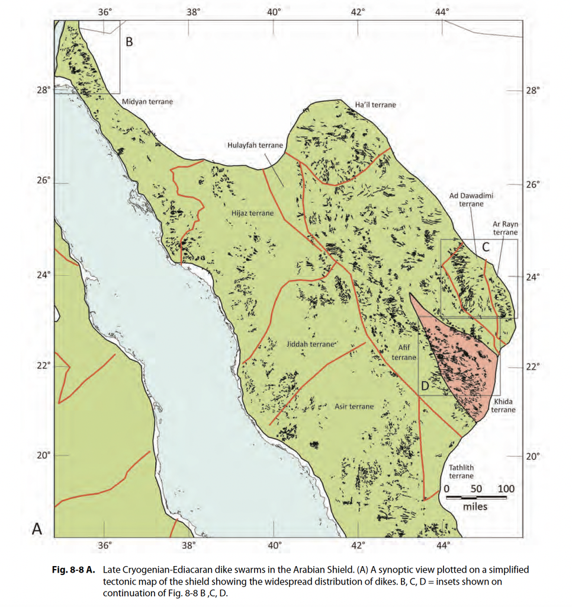

Source: Johnson PR, Kattan FH (2012) The geology of the Saudi Arabian shield: Saudi geological survey: Jeddah, Saudi Arabia, pp 1–479

- Late Cryogenian-Ediacaran mafic, felsic, and composite dikes are widespread across the Arabian Shield
- Similarly abundant in the Nubian Shield, Sinai, and Jordan
- These dikes are unambiguous evidence of crustal extension during the final stages of shield development
- They cross-cut most other rocks and structures
- Represent some of the youngest Neoproterozoic rocks in any given area of the shield

### Physical Characteristics

- Occur in linear or curved swarms
  - Thickness varies from a few centimeters to meters
  - Length from several meters to tens of kilometers
- Within any area:
  - Dikes commonly share a dominant strike
  - Or form conjugate systems with intersecting strikes
- Mostly subvertical
  - Predominantly rhyolitic
  - Also include basalt and andesite
- Bimodal swarms:
  - Andesite and rhyolite
  - Intrusive relationships indicating synchronous emplacement of mafic and felsic magma
- Composite dikes:
  - Individually bimodal
  - Felsic cores and mafic external parts
  - Implying rapid injection of contrasting magmas along the same conduit

# Petrogenesis and Magmatic Evolution

- Petrogenesis = study of rock origin
  - Integrates mineralogy, chemistry, geochronology, and tectonics
- Key questions for the Arabian Shield:
  - What generated the large volumes of magma?
  - Why did magma composition change through time?

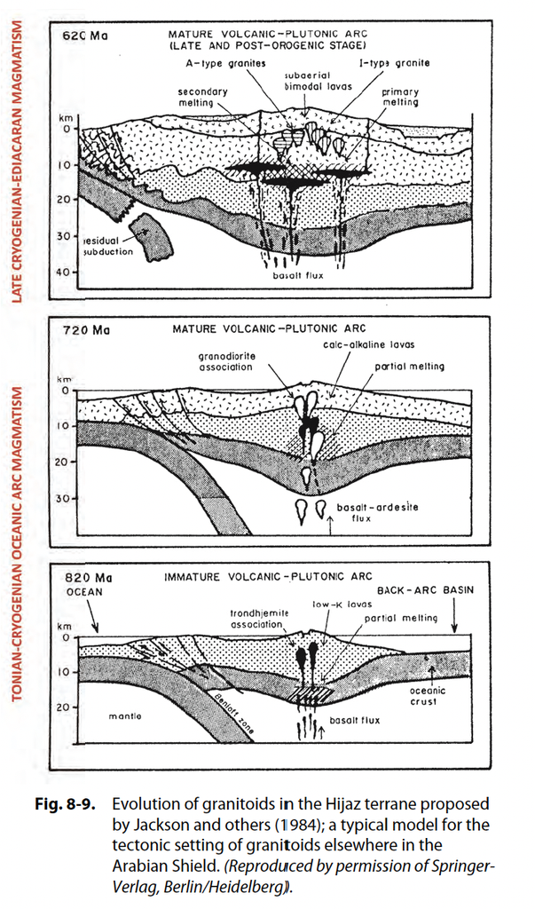

Source: Johnson PR, Kattan FH (2012) The geology of the Saudi Arabian shield: Saudi geological survey: Jeddah, Saudi Arabia, pp 1–479

### Island-Arc Stage (I-Type, TTG)

- Magmatism linked to subduction zones
- Three plutonic associations:
  - Granodiorite association
  - Tonalite association
  - Trondhjemite association

### Post-Accretionary Evolution

- Three granite groups:
  - High Ca–Mg (monzogranite, granodiorite)
  - Moderate Ca–Mg (syenogranite)
  - Low Ca–Mg (alkali-feldspar granite, A-type)
- Interpretation:
  - Early magmas → mantle/juvenile crust
  - Later magmas → increasing older crustal contribution
- Represents crustal maturation during the orogenic cycle

### Causes of Post-Accretionary Magmatism

- Multiple possible mechanisms:
  - Crustal thickening → partial melting
  - Continued subduction (locally)
  - Delamination → mantle upwelling
  - Shear zones (Najd faults) → pressure reduction and melting
  - Orogenic collapse → lithospheric thinning and heating
- Still an open scientific problem
- Requires integration of:
  - Geochemistry
  - Isotopes
  - Petrography
  - Geochronology

# Granite Origins — The A-Type Debate

- No general agreement on the origin of A-type granites in the Arabian Shield
- Reflects a broader global debate on granitoid origins
- Originally defined as:
  - Granites formed in extensional, anorogenic (rift) settings
- Now recognized that A-type granites occur in:
  - Multiple tectonic environments

### Proposed Genetic Models

- Several models proposed to explain A-type granite origin:

### Model 1: Depleted Granulite Melting

- Derived from anhydrous granulite (high-grade metamorphic rocks)
- Previously depleted by partial melting
- Limitation:
  - Difficult to explain enriched incompatible elements in A-type granites

### Model 2: Melting of Earlier Arc Crust

- Derived from calc-alkaline crust (diorite, tonalite, granodiorite)
- Followed by anhydrous fractionation
- Evidence:
  - Some A-types retain calc-alkaline geochemical signatures
  - (Samuel et al. 2007; Kessel et al. 1998)

### Model 3: Basalt Fractional Crystallisation

- A-type magmas form by fractionation of basaltic magma
- Supporting evidence:
  - Cogenetic rhyolite–mafic dike relationships in Sinai
  - (Kessel et al. 1998)

### Model 4: Metasomatised Mantle Melting

- Partial melting of phlogopite-bearing spinel lherzolite
- Source: subduction-modified mantle wedge
- Trigger mechanisms:
  - Slab break-off
  - Delamination
- References:
  - (Liegeois et al. 1998; Jarrar et al. 2008)

### Model 5: Mantle Origin via Shear Zones

- Example: Ablah-Shwas pluton (617–605 Ma)
- Key evidence:
  - Low initial Sr (0.7035–0.7038)
  - Close to mantle values (~615 Ma)
- Interpretation:
  - Magma derived from mantle / juvenile crust
  - Triggered by Umm Farwah shear zone (Moufti, 2001)

# The Bigger Picture

- Late Cryogenian–Ediacaran granites represent a massive emplacement of magma in the upper crust of the Arabian-Nubian Shield
- Seismic-refraction data indicate:
  - Granite dominates the upper ~20 km of crust in the shield
- Granitic infracrustal rocks exposed in gneiss domes:
  - Suggest a similar crustal structure in the Nubian Shield
- This magmatic event:
  - Involved multiple genetic processes
  - Occurred across multiple terranes
  - Spanned ~80 million years
- Represents one of the defining plutonic events of Neoproterozoic Earth history